# Projet Semestriel : Mathématiques pour le Big Data

#### **Exercice 5 : ACP**

##### **A. Analyse rapide**

**1. Récupérer les données du fichier “decathlon” et donner la matrice corrélation des variables quantitatives (ne pas prendre COMPET)**

```r
library(FactoMineR)
library(factoextra)
```

```r
library(corrplot)
deca<-read.table("decathlon.dat")

print(deca)
```

```
##              c100 long poids haut  c400  c110  disq perche javel  c1500 RANG
## SEBRLE      11.04 7.58 14.83 2.07 49.81 14.69 43.75   5.02 63.19 291.70    1
## CLAY        10.76 7.40 14.26 1.86 49.37 14.05 50.72   4.92 60.15 301.50    2
## KARPOV      11.02 7.30 14.77 2.04 48.37 14.09 48.95   4.92 50.31 300.20    3
## BERNARD     11.02 7.23 14.25 1.92 48.93 14.99 40.87   5.32 62.77 280.10    4
## YURKOV      11.34 7.09 15.19 2.10 50.42 15.31 46.26   4.72 63.44 276.40    5
## WARNERS     11.11 7.60 14.31 1.98 48.68 14.23 41.10   4.92 51.77 278.10    6
## ZSIVOCZKY   11.13 7.30 13.48 2.01 48.62 14.17 45.67   4.42 55.37 268.00    7
## McMULLEN    10.83 7.31 13.76 2.13 49.91 14.38 44.41   4.42 56.37 285.10    8
## MARTINEAU   11.64 6.81 14.57 1.95 50.14 14.93 47.60   4.92 52.33 262.10    9
## HERNU       11.37 7.56 14.41 1.86 51.10 15.06 44.99   4.82 57.19 285.10   10
## BARRAS      11.33 6.97 14.09 1.95 49.48 14.48 42.10   4.72 55.40 282.00   11
## NOOL        11.33 7.27 12.68 1.98 49.20 15.29 37.92   4.62 57.44 266.60   12
## BOURGUIGNON 11.36 6.80 13.46 1.86 51.16 15.67 40.49   5.02 54.68 291.70   13
## Sebrle      10.85 7.84 16.36 2.12 48.36 14.05 48.72   5.00 70.52 280.01    1
## Clay        10.44 7.96 15.23 2.06 49.19 14.13 50.11   4.90 69.71 282.00    2
## Karpov      10.50 7.81 15.93 2.09 46.81 13.97 51.65   4.60 55.54 278.11    3
## Macey       10.89 7.47 15.73 2.15 48.97 14.56 48.34   4.40 58.46 265.42    4
## Warners     10.62 7.74 14.48 1.97 47.97 14.01 43.73   4.90 55.39 278.05    5
## Zsivoczky   10.91 7.14 15.31 2.12 49.40 14.95 45.62   4.70 63.45 269.54    6
## Hernu       10.97 7.19 14.65 2.03 48.73 14.25 44.72   4.80 57.76 264.35    7
## Nool        10.80 7.53 14.26 1.88 48.81 14.80 42.05   5.40 61.33 276.33    8
## Bernard     10.69 7.48 14.80 2.12 49.13 14.17 44.75   4.40 55.27 276.31    9
## Schwarzl    10.98 7.49 14.01 1.94 49.76 14.25 42.43   5.10 56.32 273.56   10
## Pogorelov   10.95 7.31 15.10 2.06 50.79 14.21 44.60   5.00 53.45 287.63   11
## Schoenbeck  10.90 7.30 14.77 1.88 50.30 14.34 44.41   5.00 60.89 278.82   12
## Barras      11.14 6.99 14.91 1.94 49.41 14.37 44.83   4.60 64.55 267.09   13
## Smith       10.85 6.81 15.24 1.91 49.27 14.01 49.02   4.20 61.52 272.74   14
## Averyanov   10.55 7.34 14.44 1.94 49.72 14.39 39.88   4.80 54.51 271.02   15
## Ojaniemi    10.68 7.50 14.97 1.94 49.12 15.01 40.35   4.60 59.26 275.71   16
## Smirnov     10.89 7.07 13.88 1.94 49.11 14.77 42.47   4.70 60.88 263.31   17
## Qi          11.06 7.34 13.55 1.97 49.65 14.78 45.13   4.50 60.79 272.63   18
## Drews       10.87 7.38 13.07 1.88 48.51 14.01 40.11   5.00 51.53 274.21   19
## Parkhomenko 11.14 6.61 15.69 2.03 51.04 14.88 41.90   4.80 65.82 277.94   20
## Terek       10.92 6.94 15.15 1.94 49.56 15.12 45.62   5.30 50.62 290.36   21
## Gomez       11.08 7.26 14.57 1.85 48.61 14.41 40.95   4.40 60.71 269.70   22
## Turi        11.08 6.91 13.62 2.03 51.67 14.26 39.83   4.80 59.34 290.01   23
## Lorenzo     11.10 7.03 13.22 1.85 49.34 15.38 40.22   4.50 58.36 263.08   24
## Karlivans   11.33 7.26 13.30 1.97 50.54 14.98 43.34   4.50 52.92 278.67   25
## Korkizoglou 10.86 7.07 14.81 1.94 51.16 14.96 46.07   4.70 53.05 317.00   26
```

[output cut: 29 more lines]

```
## Smith         8023 OlympicG
## Averyanov     8021 OlympicG
## Ojaniemi      8006 OlympicG
## Smirnov       7993 OlympicG
## Qi            7934 OlympicG
## Drews         7926 OlympicG
## Parkhomenko   7918 OlympicG
## Terek         7893 OlympicG
## Gomez         7865 OlympicG
## Turi          7708 OlympicG
## Lorenzo       7592 OlympicG
## Karlivans     7583 OlympicG
## Korkizoglou   7573 OlympicG
## Uldal         7495 OlympicG
## Casarsa       7404 OlympicG
```

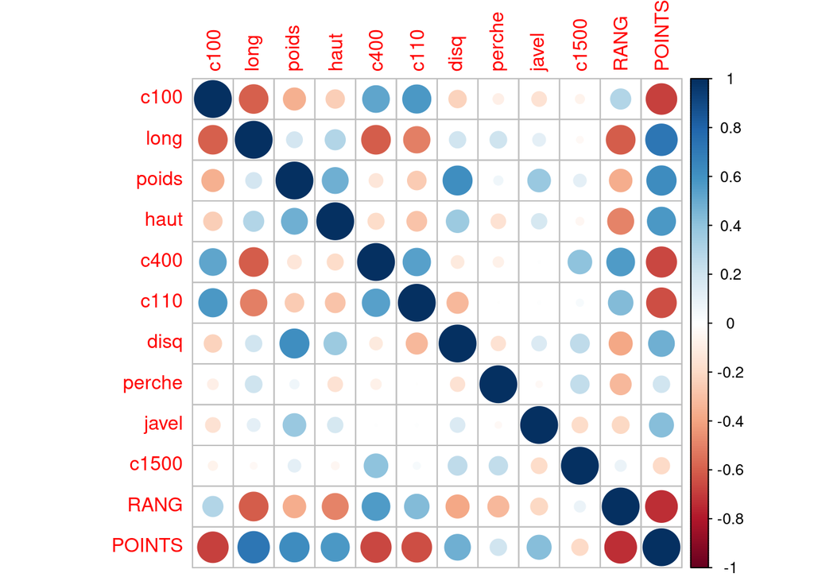

```r
corrplot(cor(deca[ , !(names(deca) %in% c("COMPET"))]))
```

**2. Quelles sont les couples de variables les plus corrélées, les moins corrélées, les plus opposées ? Justifier.**

Les couples de variables les plus corrélés sont :

- POINTS –> LONGEUR
- POINTS –> POIDS
- C110 –> C100
- C400 –> C100
- Disque –> Poids
- C110 –> C400
- Rang –> C400

On voit que les épreuves de lancer et les épreuves de courses sont corrélées entre elles

Les moins corrélées sont :

- C1500 –> C100
- C1500 –> Long
- Perche –> Poids
- C1500 –> Poids
- C1500 –> Haut
- Perche –> C400
- Javel –> C400
- Perche –> C110
- Javel –> C110
- C1500 –> C110
- Rang –> C1500

Les moins corrélées sont les épreuves les plus différentes.

Les plus opposées :

- C100 –> long
- C100 –> POINTS
- long –> C400
- long –> Rang
- Point –> C400
- Point –> C110
- Point –> Rang

**3. Comment se groupent les variables du point de vue des signes de corrélation ? Expliquez pourquoi.**

- Les épreuves concernant des sports similaires montrent une corrélation positive (course et lancer).
- Une corrélation négative apparait entre le rang et le score, cela s’explique, car il faut avoir un score élevé pour avoir un rang faible.

##### **B. ACP : dans cette partie, vous allez procédez à une analyse en composantes principales des performances centrées-réduites, en excluant les variables RANG, POINTS et COMPET.**

**4. Donner les valeurs propres de la matrice de corrélation. Trier ces valeurs propres et donner le nombre de vecteurs propres qui expliquent le plus l’inertie du nuage des individus. Quelle règle peut-on utiliser ? Donner le pourcentage d’inertie totale en conservant les trois premiers vecteurs propres.**

```r
deca<-deca[ , !(names(deca) %in% c("COMPET","RANG","POINTS"))]
correlation<-cor(deca)
ev<-eigen(correlation)$values
ev
```

```
##  [1] 3.2719055380 1.7371310231 1.4049166821 1.0568503533 0.6847735349
##  [6] 0.5992686808 0.4512352638 0.3968765857 0.2148148532 0.1822274851
```

```r
sort(ev, decreasing = T)
```

```
##  [1] 3.2719055380 1.7371310231 1.4049166821 1.0568503533 0.6847735349
##  [6] 0.5992686808 0.4512352638 0.3968765857 0.2148148532 0.1822274851
```

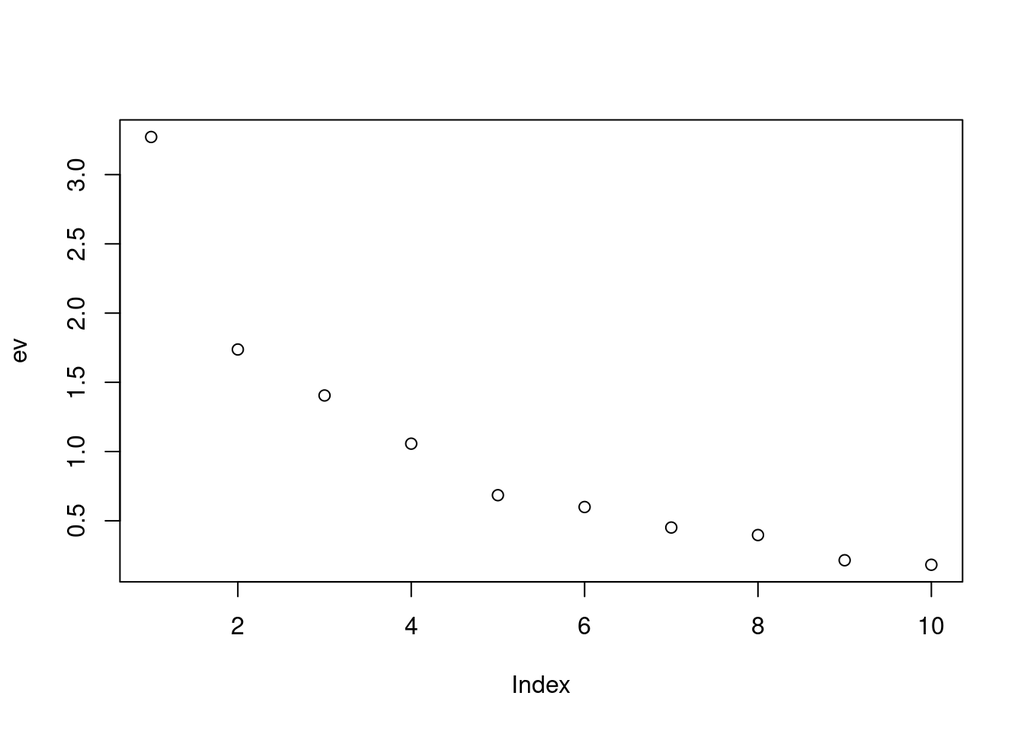

```r
plot(ev)
```

On utilise la règle du coude, la cassure apparait pour la cinquième valeur propre.

```r
sum((sort(ev,decreasing = T) / sum(ev))[1:3])
```

```
## [1] 0.6413953243
```

64% de l’inertie est expliquée par les trois premières valeurs propres.

**5. Déterminer les trois composantes principales (projection des individus sur les trois vecteurs propres), que l’on note $C1$, $C2$, $C3$ dans l’ordre décroisant d’inertie.**

```r
res.pca <- PCA(deca, graph = F)
#Q5
#Composantes principales
ind <- get_pca_ind(res.pca)
ind$coord[,1:3]
```

```
##                       Dim.1          Dim.2            Dim.3
## SEBRLE       0.791627716890  0.77161119552  0.8268411940268
## CLAY         1.234990562922  0.57457806534  2.1412469663713
## KARPOV       1.358214935758  0.48402090113  1.9562579868954
## BERNARD     -0.609515083106 -0.87462852884  0.8899406618588
## YURKOV      -0.585968337761  2.13095422255 -1.2251567968084
## WARNERS      0.356889530489 -1.68495666583  0.7665531449198
## ZSIVOCZKY    0.271774781024 -1.09377557750 -1.2827673831291
## McMULLEN     0.587516189056  0.23072991176 -0.4176329823038
## MARTINEAU   -1.995359298025  0.56099598158 -0.7299466010890
## HERNU       -1.546076461677  0.48838301094  0.8407858519275
## BARRAS      -1.341652726752 -0.31091157069 -0.0003683375477
## NOOL        -2.344973805586 -1.96637500055 -1.3364815492290
## BOURGUIGNON -3.979041864579  0.19986018993  1.3264851034113
## Sebrle       4.038448501441  1.36582606354 -0.2899565042806
## Clay         3.919365157228  0.83696136260  0.2311753204792
## Karpov       4.619987275045  0.03999522890 -0.0415857980014
## Macey        2.233460565598  1.04176620064 -1.8643620154049
## Warners      2.168396445406 -1.80320025033  0.8510173287098
## Zsivoczky    0.925132182894  1.16865179610 -1.4774802908286
## Hernu        0.889037851513 -0.61842521554 -0.8982953479746
## Nool         0.295305666684 -1.54561667242  1.3552601285624
## Bernard      1.906334367677 -0.08580429180 -0.7571859708851
## Schwarzl     0.081078659392 -1.35345709932  0.8224866222304
## Pogorelov    0.539677027745  0.77075098970  1.3476197769273
## Schoenbeck   0.114430984607 -0.03985060809  0.7404039810320
## Barras       0.002145202768  0.36033768481 -1.5696934887659
## Smith        0.870310569720  1.05932551998 -1.6434290616483
## Averyanov    0.349155137968 -1.55864999153  0.2825354036679
## Ojaniemi     0.380113998692 -0.77244734296 -0.3709431418934
## Smirnov     -0.484514212539 -1.06066118077 -1.2283378499303
## Qi          -0.434466690806 -0.32614689717 -1.0697978122896
## Drews       -0.248684024375 -3.08167683010  1.0548427374522
## Parkhomenko -1.069429104277  2.09318217909 -0.9999839028901
## Terek       -0.681953059148  0.53561439799  2.2091259997098
## Gomez       -0.289889207723 -1.19671610589 -1.3061025895306
## Turi        -1.541813055585  0.42716772525  0.5140859441357
## Lorenzo     -2.408509979550 -1.58292969328 -1.5023461069170
## Karlivans   -1.994368726831 -0.29418239625 -0.3427836936915
## Korkizoglou -0.957829813261  2.06638553650  2.5865525262672
## Uldal       -2.562259590728  0.24546870508 -0.4191406444668
## Casarsa     -2.857088268209  3.79784504993  0.0305611909207
```

```r
C1<-ind$coord[,1]
C2<-ind$coord[,2]
C3<-ind$coord[,3]
```

**6. Déterminer le tableau des corrélations des variables par rapport à $C1, C2, C3$ et donner les deux cercles de corrélation des variables par rapport à $(C1, C2)$ et $(C2, C3)$**

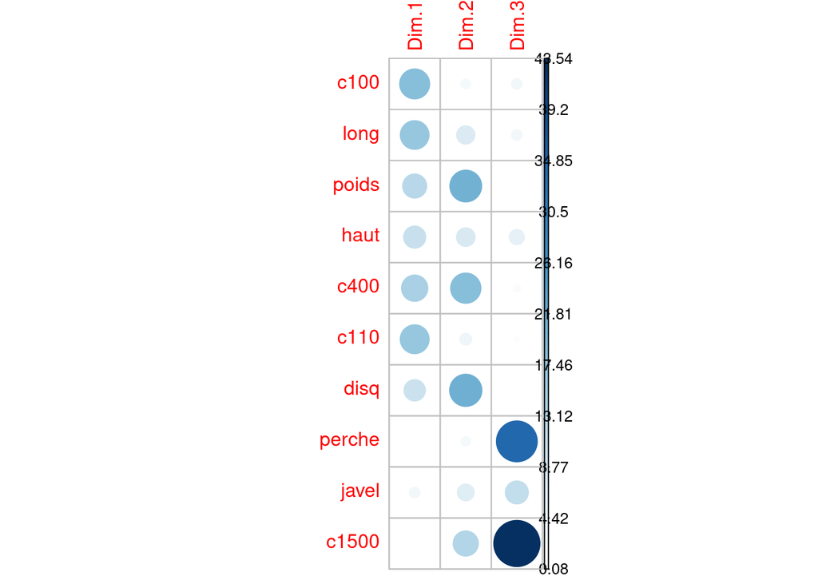

```r
var <- get_pca_var(res.pca)
corrplot(var$contrib[,c(1:3)], is.corr=FALSE)
```

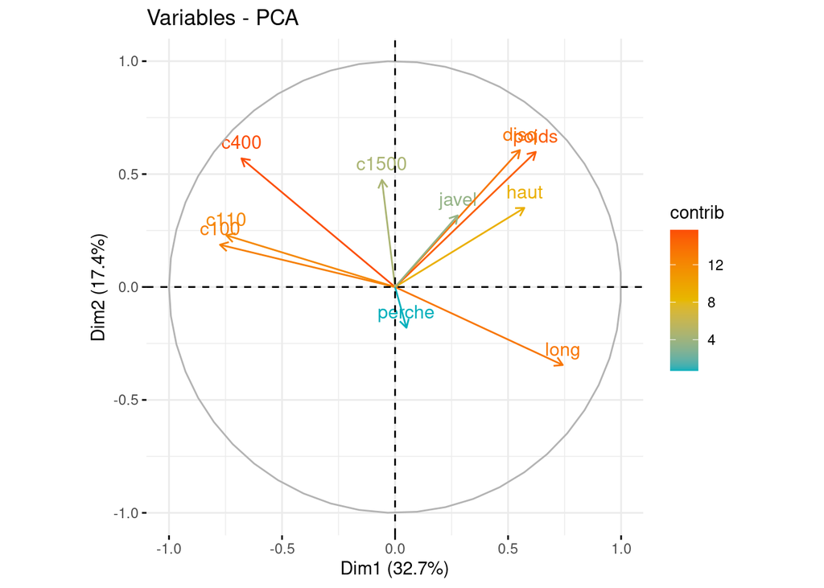

```r
fviz_pca_var(res.pca, col.var = "contrib", gradient.cols = c("#00AFBB", "#E7B800", "#FC4E07") , axes = c(1,2))
```

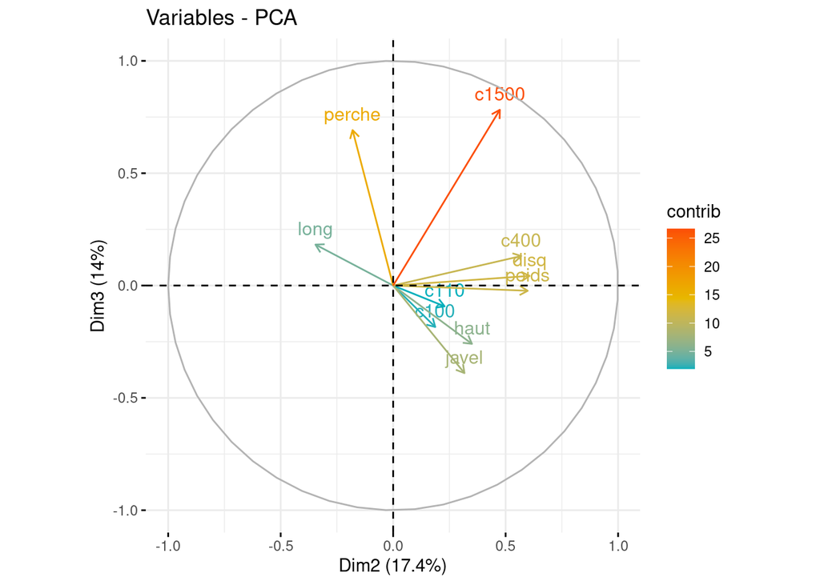

```r
fviz_pca_var(res.pca, col.var = "contrib", gradient.cols = c("#00AFBB", "#E7B800", "#FC4E07") , axes = c(2,3))
```

**7. Quelles sont les variables qui déterminent les 3 composantes principales ? Proposez un seuil.**

```r
res.desc <- dimdesc(res.pca, axes = c(1,2,3), proba = 0.05)
res.desc$Dim.1$quanti
```

```
##         correlation         p.value
## long   0.7418997450 2.849885834e-08
## poids  0.6225025511 1.388320670e-05
## haut   0.5719452960 9.362284801e-05
## disq   0.5524665193 1.802219952e-04
## c400  -0.6796099427 1.028174558e-06
## c110  -0.7462453240 2.136961517e-08
## c100  -0.7747198283 2.778466580e-09
```

```r
res.desc$Dim.2$quanti
```

```
##         correlation         p.value
## disq   0.6063133911 2.650744528e-05
## poids  0.5983033207 3.603567348e-05
## c400   0.5694377766 1.020941249e-04
## c1500  0.4742237687 1.734405284e-03
## haut   0.3502936078 2.475025040e-02
## javel  0.3169890605 4.344974126e-02
## long  -0.3454212938 2.696968984e-02
```

```r
res.desc$Dim.3$quanti
```

```
##          correlation         p.value
## c1500   0.7821428011 1.554449692e-09
## perche  0.6917566549 5.480171723e-07
## javel  -0.3896554074 1.179330939e-02
```

Nous proposons un seuil de 33% de la valeur absolue de la corrélation.

**8. Expliquez comment les données peuvent être modifiées pour faire apparaître un effet de taille. Comment peut-on alors interpréter les axes principaux de la question 5 ?**

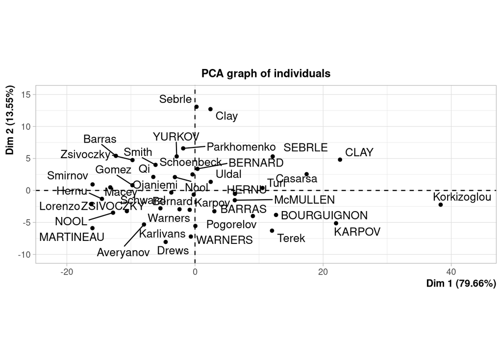

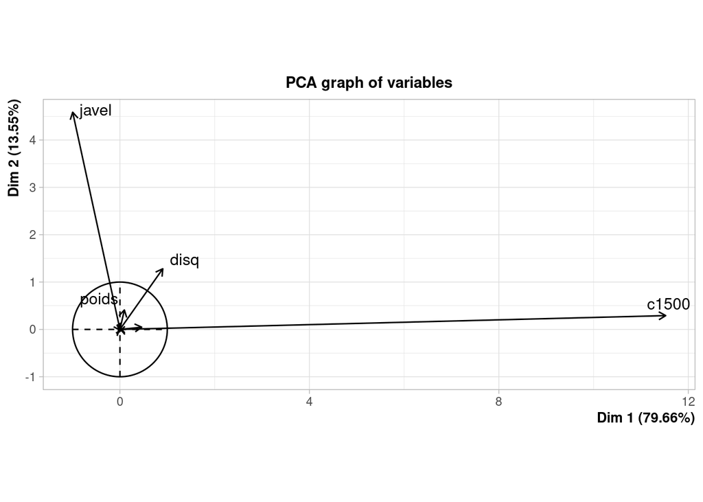

```r
taille.pca <- PCA(deca, graph = T, scale.unit = F)
```

```r
taille.desc <- dimdesc(taille.pca, axes = c(1,2), proba = 0.05)
taille.desc$Dim.1$quanti
```

```
##        correlation         p.value
## c1500 0.9993506388 6.526966095e-58
## c400  0.4032299240 8.945953729e-03
```

```r
taille.desc$Dim.2$quanti
```

```
##        correlation         p.value
## javel 0.9619837766 1.369499988e-23
## poids 0.5038617740 7.835507265e-04
## disq  0.3837681440 1.324971777e-02
```